# IPL(2008-2019) Data Analysis

Cricket is a bat-and-ball game played between two teams of eleven players each on a cricket field, at the centre of which is a rectangular 20-metre (22-yard) pitch with a target at each end called the wicket (a set of three wooden stumps upon which two bails sit). Each phase of play is called an innings, during which one team bats, attempting to score as many runs as possible, whilst their opponents bowl and field, attempting to minimise the number of runs scored. When each innings ends, the teams usually swap roles for the next innings (i.e. the team that previously batted will bowl/field, and vice versa). The teams each bat for one or two innings, depending on the type of match. The winning team is the one that scores the most runs, including any extras gained (except when the result is not a win/loss result). Source: https://en.wikipedia.org/wiki/Cricket

[figure not shown]

```python
from IPython.display import Image
Image(filename="C:/Users/kavya/Desktop/PYTHON/MTECH DSML/Python Images&PPT/Certificates/ipl.jpg")
```

# Importing required libraries

```python
import pandas as pd
import matplotlib.pyplot as plt
import plotly.express as px
from plotly.subplots import make_subplots
import plotly.graph_objects as go
import seaborn as sns
%matplotlib inline
```

# About Datasets

The dataset d_matches consists of data from the Season 2008 to 2019 that gives information regarding the location,matches played between various teams and the winners in each match and much more.The dataset d_deliveries further talks about which team will be batting and bowling, along with which player was batting or bowling in each inning.The dataset d_teams tells us the names of different teams that play in IPL.And finally the dataset d_team_hna talks about the matches held in home city and away and gives an eloborate detail of the same.

# Loading Datasets

```python
d_matches=pd.read_csv('C:/Users/kavya/Downloads/archive/matches.csv')
d_deliveries=pd.read_csv('C:/Users/kavya/Downloads/archive/deliveries.csv')
d_teams=pd.read_csv('C:/Users/kavya/Downloads/archive/teams.csv')
d_team_hna=pd.read_csv('C:/Users/kavya/Downloads/archive/teamwise_home_and_away.csv')
```

```python
d_matches.head()
```

|  | id | Season | city | date | team1 | team2 | toss_winner | toss_decision | result | dl_applied | winner | win_by_runs | win_by_wickets | player_of_match | venue | umpire1 | umpire2 | umpire3 |
| --- | --- | --- | --- | --- | --- | --- | --- | --- | --- | --- | --- | --- | --- | --- | --- | --- | --- | --- |
| 0 | 1 | IPL-2017 | Hyderabad | 05-04-2017 | Sunrisers Hyderabad | Royal Challengers Bangalore | Royal Challengers Bangalore | field | normal | 0 | Sunrisers Hyderabad | 35 | 0 | Yuvraj Singh | Rajiv Gandhi International Stadium, Uppal | AY Dandekar | NJ Llong | NaN |
| 1 | 2 | IPL-2017 | Pune | 06-04-2017 | Mumbai Indians | Rising Pune Supergiant | Rising Pune Supergiant | field | normal | 0 | Rising Pune Supergiant | 0 | 7 | SPD Smith | Maharashtra Cricket Association Stadium | A Nand Kishore | S Ravi | NaN |
| 2 | 3 | IPL-2017 | Rajkot | 07-04-2017 | Gujarat Lions | Kolkata Knight Riders | Kolkata Knight Riders | field | normal | 0 | Kolkata Knight Riders | 0 | 10 | CA Lynn | Saurashtra Cricket Association Stadium | Nitin Menon | CK Nandan | NaN |
| 3 | 4 | IPL-2017 | Indore | 08-04-2017 | Rising Pune Supergiant | Kings XI Punjab | Kings XI Punjab | field | normal | 0 | Kings XI Punjab | 0 | 6 | GJ Maxwell | Holkar Cricket Stadium | AK Chaudhary | C Shamshuddin | NaN |
| 4 | 5 | IPL-2017 | Bangalore | 08-04-2017 | Royal Challengers Bangalore | Delhi Daredevils | Royal Challengers Bangalore | bat | normal | 0 | Royal Challengers Bangalore | 15 | 0 | KM Jadhav | M Chinnaswamy Stadium | NaN | NaN | NaN |

```python
d_deliveries.head()
```

|  | match_id | inning | batting_team | bowling_team | over | ball | batsman | non_striker | bowler | is_super_over | ... | bye_runs | legbye_runs | noball_runs | penalty_runs | batsman_runs | extra_runs | total_runs | player_dismissed | dismissal_kind | fielder |
| --- | --- | --- | --- | --- | --- | --- | --- | --- | --- | --- | --- | --- | --- | --- | --- | --- | --- | --- | --- | --- | --- |
| 0 | 1 | 1 | Sunrisers Hyderabad | Royal Challengers Bangalore | 1 | 1 | DA Warner | S Dhawan | TS Mills | 0 | ... | 0 | 0 | 0 | 0 | 0 | 0 | 0 | NaN | NaN | NaN |
| 1 | 1 | 1 | Sunrisers Hyderabad | Royal Challengers Bangalore | 1 | 2 | DA Warner | S Dhawan | TS Mills | 0 | ... | 0 | 0 | 0 | 0 | 0 | 0 | 0 | NaN | NaN | NaN |
| 2 | 1 | 1 | Sunrisers Hyderabad | Royal Challengers Bangalore | 1 | 3 | DA Warner | S Dhawan | TS Mills | 0 | ... | 0 | 0 | 0 | 0 | 4 | 0 | 4 | NaN | NaN | NaN |
| 3 | 1 | 1 | Sunrisers Hyderabad | Royal Challengers Bangalore | 1 | 4 | DA Warner | S Dhawan | TS Mills | 0 | ... | 0 | 0 | 0 | 0 | 0 | 0 | 0 | NaN | NaN | NaN |
| 4 | 1 | 1 | Sunrisers Hyderabad | Royal Challengers Bangalore | 1 | 5 | DA Warner | S Dhawan | TS Mills | 0 | ... | 0 | 0 | 0 | 0 | 0 | 2 | 2 | NaN | NaN | NaN |

5 rows × 21 columns

```python
d_teams
```

|  | team1 |
| --- | --- |
| 0 | Pune Warriors |
| 1 | Kolkata Knight Riders |
| 2 | Rajasthan Royals |
| 3 | Kochi Tuskers Kerala |
| 4 | Gujarat Lions |
| 5 | Chennai Super Kings |
| 6 | Rising Pune Supergiants |
| 7 | Delhi Daredevils |
| 8 | Deccan Chargers |
| 9 | Delhi Capitals |
| 10 | Mumbai Indians |
| 11 | Sunrisers Hyderabad |
| 12 | Rising Pune Supergiant |
| 13 | Royal Challengers Bangalore |
| 14 | Kings XI Punjab |

```python
d_team_hna
```

|  | team | home_wins | away_wins | home_matches | away_matches | home_win_percentage | away_win_percentage |
| --- | --- | --- | --- | --- | --- | --- | --- |
| 0 | Rising Pune Supergiant | 5 | 5 | 8 | 8 | 62.500000 | 62.500000 |
| 1 | Mumbai Indians | 58 | 51 | 101 | 86 | 57.425743 | 59.302326 |
| 2 | Chennai Super Kings | 51 | 49 | 89 | 75 | 57.303371 | 65.333333 |
| 3 | Delhi Capitals | 3 | 7 | 6 | 10 | 50.000000 | 70.000000 |
| 4 | Sunrisers Hyderabad | 30 | 28 | 63 | 45 | 47.619048 | 62.222222 |
| 5 | Rajasthan Royals | 29 | 46 | 67 | 80 | 43.283582 | 57.500000 |
| 6 | Deccan Chargers | 18 | 11 | 43 | 32 | 41.860465 | 34.375000 |
| 7 | Kings XI Punjab | 38 | 44 | 91 | 85 | 41.758242 | 51.764706 |
| 8 | Royal Challengers Bangalore | 35 | 49 | 85 | 95 | 41.176471 | 51.578947 |
| 9 | Kolkata Knight Riders | 34 | 58 | 83 | 95 | 40.963855 | 61.052632 |
| 10 | Delhi Daredevils | 25 | 42 | 72 | 89 | 34.722222 | 47.191011 |
| 11 | Pune Warriors | 6 | 6 | 20 | 26 | 30.000000 | 23.076923 |
| 12 | Kochi Tuskers Kerala | 2 | 4 | 7 | 7 | 28.571429 | 57.142857 |
| 13 | Gujarat Lions | 1 | 12 | 14 | 16 | 7.142857 | 75.000000 |

# Data Cleaning

### Checking For Nan values in each dataset

```python
(d_matches.isna().sum()/len(d_matches))*100
```

```
id                  0.000000
Season              0.000000
city                0.925926
date                0.000000
team1               0.000000
team2               0.000000
toss_winner         0.000000
toss_decision       0.000000
result              0.000000
dl_applied          0.000000
winner              0.529101
win_by_runs         0.000000
win_by_wickets      0.000000
player_of_match     0.529101
venue               0.000000
umpire1             0.264550
umpire2             0.264550
umpire3            84.259259
dtype: float64
```

```python
d_matches.drop(labels='umpire3',axis=1,inplace=True)
```

```python
d_matches[d_matches.city.isnull()]
```

|  | id | Season | city | date | team1 | team2 | toss_winner | toss_decision | result | dl_applied | winner | win_by_runs | win_by_wickets | player_of_match | venue | umpire1 | umpire2 |
| --- | --- | --- | --- | --- | --- | --- | --- | --- | --- | --- | --- | --- | --- | --- | --- | --- | --- |
| 461 | 462 | IPL-2014 | NaN | 19-04-2014 | Mumbai Indians | Royal Challengers Bangalore | Royal Challengers Bangalore | field | normal | 0 | Royal Challengers Bangalore | 0 | 7 | PA Patel | Dubai International Cricket Stadium | Aleem Dar | AK Chaudhary |
| 462 | 463 | IPL-2014 | NaN | 19-04-2014 | Kolkata Knight Riders | Delhi Daredevils | Kolkata Knight Riders | bat | normal | 0 | Delhi Daredevils | 0 | 4 | JP Duminy | Dubai International Cricket Stadium | Aleem Dar | VA Kulkarni |
| 466 | 467 | IPL-2014 | NaN | 23-04-2014 | Chennai Super Kings | Rajasthan Royals | Rajasthan Royals | field | normal | 0 | Chennai Super Kings | 7 | 0 | RA Jadeja | Dubai International Cricket Stadium | HDPK Dharmasena | RK Illingworth |
| 468 | 469 | IPL-2014 | NaN | 25-04-2014 | Sunrisers Hyderabad | Delhi Daredevils | Sunrisers Hyderabad | bat | normal | 0 | Sunrisers Hyderabad | 4 | 0 | AJ Finch | Dubai International Cricket Stadium | M Erasmus | S Ravi |
| 469 | 470 | IPL-2014 | NaN | 25-04-2014 | Mumbai Indians | Chennai Super Kings | Mumbai Indians | bat | normal | 0 | Chennai Super Kings | 0 | 7 | MM Sharma | Dubai International Cricket Stadium | BF Bowden | M Erasmus |
| 474 | 475 | IPL-2014 | NaN | 28-04-2014 | Royal Challengers Bangalore | Kings XI Punjab | Kings XI Punjab | field | normal | 0 | Kings XI Punjab | 0 | 5 | Sandeep Sharma | Dubai International Cricket Stadium | BF Bowden | S Ravi |
| 476 | 477 | IPL-2014 | NaN | 30-04-2014 | Sunrisers Hyderabad | Mumbai Indians | Mumbai Indians | field | normal | 0 | Sunrisers Hyderabad | 15 | 0 | B Kumar | Dubai International Cricket Stadium | HDPK Dharmasena | M Erasmus |

### Replacing Nan values from city column after comparison with venue column

```python
d_matches.loc[d_matches.venue=='Dubai International Cricket Stadium']
```

|  | id | Season | city | date | team1 | team2 | toss_winner | toss_decision | result | dl_applied | winner | win_by_runs | win_by_wickets | player_of_match | venue | umpire1 | umpire2 |
| --- | --- | --- | --- | --- | --- | --- | --- | --- | --- | --- | --- | --- | --- | --- | --- | --- | --- |
| 461 | 462 | IPL-2014 | NaN | 19-04-2014 | Mumbai Indians | Royal Challengers Bangalore | Royal Challengers Bangalore | field | normal | 0 | Royal Challengers Bangalore | 0 | 7 | PA Patel | Dubai International Cricket Stadium | Aleem Dar | AK Chaudhary |
| 462 | 463 | IPL-2014 | NaN | 19-04-2014 | Kolkata Knight Riders | Delhi Daredevils | Kolkata Knight Riders | bat | normal | 0 | Delhi Daredevils | 0 | 4 | JP Duminy | Dubai International Cricket Stadium | Aleem Dar | VA Kulkarni |
| 466 | 467 | IPL-2014 | NaN | 23-04-2014 | Chennai Super Kings | Rajasthan Royals | Rajasthan Royals | field | normal | 0 | Chennai Super Kings | 7 | 0 | RA Jadeja | Dubai International Cricket Stadium | HDPK Dharmasena | RK Illingworth |
| 468 | 469 | IPL-2014 | NaN | 25-04-2014 | Sunrisers Hyderabad | Delhi Daredevils | Sunrisers Hyderabad | bat | normal | 0 | Sunrisers Hyderabad | 4 | 0 | AJ Finch | Dubai International Cricket Stadium | M Erasmus | S Ravi |
| 469 | 470 | IPL-2014 | NaN | 25-04-2014 | Mumbai Indians | Chennai Super Kings | Mumbai Indians | bat | normal | 0 | Chennai Super Kings | 0 | 7 | MM Sharma | Dubai International Cricket Stadium | BF Bowden | M Erasmus |
| 474 | 475 | IPL-2014 | NaN | 28-04-2014 | Royal Challengers Bangalore | Kings XI Punjab | Kings XI Punjab | field | normal | 0 | Kings XI Punjab | 0 | 5 | Sandeep Sharma | Dubai International Cricket Stadium | BF Bowden | S Ravi |
| 476 | 477 | IPL-2014 | NaN | 30-04-2014 | Sunrisers Hyderabad | Mumbai Indians | Mumbai Indians | field | normal | 0 | Sunrisers Hyderabad | 15 | 0 | B Kumar | Dubai International Cricket Stadium | HDPK Dharmasena | M Erasmus |

```python
d_matches.city.fillna('Dubai',inplace=True)
```

```python
d_matches.dropna(axis=0,subset=['winner','player_of_match'],inplace=True)
```

```python
d_matches.dropna(axis=0,subset=['umpire1','umpire2'],inplace=True)
```

```python
(d_deliveries.isna().sum()/len(d_deliveries))*100
```

```
match_id             0.000000
inning               0.000000
batting_team         0.000000
bowling_team         0.000000
over                 0.000000
ball                 0.000000
batsman              0.000000
non_striker          0.000000
bowler               0.000000
is_super_over        0.000000
wide_runs            0.000000
bye_runs             0.000000
legbye_runs          0.000000
noball_runs          0.000000
penalty_runs         0.000000
batsman_runs         0.000000
extra_runs           0.000000
total_runs           0.000000
player_dismissed    95.066954
dismissal_kind      95.066954
fielder             96.399334
dtype: float64
```

```python
d_deliveries.drop(axis=1,columns=['player_dismissed','dismissal_kind','fielder'])
```

|  | match_id | inning | batting_team | bowling_team | over | ball | batsman | non_striker | bowler | is_super_over | wide_runs | bye_runs | legbye_runs | noball_runs | penalty_runs | batsman_runs | extra_runs | total_runs |
| --- | --- | --- | --- | --- | --- | --- | --- | --- | --- | --- | --- | --- | --- | --- | --- | --- | --- | --- |
| 0 | 1 | 1 | Sunrisers Hyderabad | Royal Challengers Bangalore | 1 | 1 | DA Warner | S Dhawan | TS Mills | 0 | 0 | 0 | 0 | 0 | 0 | 0 | 0 | 0 |
| 1 | 1 | 1 | Sunrisers Hyderabad | Royal Challengers Bangalore | 1 | 2 | DA Warner | S Dhawan | TS Mills | 0 | 0 | 0 | 0 | 0 | 0 | 0 | 0 | 0 |
| 2 | 1 | 1 | Sunrisers Hyderabad | Royal Challengers Bangalore | 1 | 3 | DA Warner | S Dhawan | TS Mills | 0 | 0 | 0 | 0 | 0 | 0 | 4 | 0 | 4 |
| 3 | 1 | 1 | Sunrisers Hyderabad | Royal Challengers Bangalore | 1 | 4 | DA Warner | S Dhawan | TS Mills | 0 | 0 | 0 | 0 | 0 | 0 | 0 | 0 | 0 |
| 4 | 1 | 1 | Sunrisers Hyderabad | Royal Challengers Bangalore | 1 | 5 | DA Warner | S Dhawan | TS Mills | 0 | 2 | 0 | 0 | 0 | 0 | 0 | 2 | 2 |
| ... | ... | ... | ... | ... | ... | ... | ... | ... | ... | ... | ... | ... | ... | ... | ... | ... | ... | ... |
| 179073 | 11415 | 2 | Chennai Super Kings | Mumbai Indians | 20 | 2 | RA Jadeja | SR Watson | SL Malinga | 0 | 0 | 0 | 0 | 0 | 0 | 1 | 0 | 1 |
| 179074 | 11415 | 2 | Chennai Super Kings | Mumbai Indians | 20 | 3 | SR Watson | RA Jadeja | SL Malinga | 0 | 0 | 0 | 0 | 0 | 0 | 2 | 0 | 2 |
| 179075 | 11415 | 2 | Chennai Super Kings | Mumbai Indians | 20 | 4 | SR Watson | RA Jadeja | SL Malinga | 0 | 0 | 0 | 0 | 0 | 0 | 1 | 0 | 1 |
| 179076 | 11415 | 2 | Chennai Super Kings | Mumbai Indians | 20 | 5 | SN Thakur | RA Jadeja | SL Malinga | 0 | 0 | 0 | 0 | 0 | 0 | 2 | 0 | 2 |
| 179077 | 11415 | 2 | Chennai Super Kings | Mumbai Indians | 20 | 6 | SN Thakur | RA Jadeja | SL Malinga | 0 | 0 | 0 | 0 | 0 | 0 | 0 | 0 | 0 |

179078 rows × 18 columns

```python
(d_teams.isnull().sum()/len(d_teams))*100
```

```
team1    0.0
dtype: float64
```

```python
(d_team_hna.isnull().sum()/len(d_team_hna))*100
```

```
team                   0.0
home_wins              0.0
away_wins              0.0
home_matches           0.0
away_matches           0.0
home_win_percentage    0.0
away_win_percentage    0.0
dtype: float64
```

# Data Analysis

### 1. Number of matches in respective locations

```python
px.bar(d_matches.groupby(by='city')[['date']].count(),text='value',color_discrete_sequence= ['seagreen'],labels={'value':'No.of days'},title='No.of matches played in each city')
```

[interactive chart not shown]

### 2. Wins by Respective Teams after winning the toss

```python
d_matches.toss_winner==d_matches.winner
df=d_matches[(d_matches.toss_winner==d_matches.winner)].groupby('winner')[['toss_winner']].count().sort_values('toss_winner')
px.line(df,x=df.index,y=df.toss_winner.values,color_discrete_sequence=['red'],labels={'winner':'teams','y':'Matches won'},title='Matches won by teams after winning the toss')
```

[interactive chart not shown]

### 3. Wins procured by teams in their home city

```python
px.pie(d_team_hna,names='team',values='home_wins',color_discrete_sequence=px.colors.sequential.Plasma_r,title='Percentage of home wins')
```

[interactive chart not shown]

### 4. Comparison between home wins and away wins by each team

```python
px.line(d_team_hna.groupby('team')[['home_wins','away_wins']].sum(),color_discrete_sequence=['darkorchid','magenta'],labels={'value':'No. of wins'},title='Comparison of wins')
```

[interactive chart not shown]

### 5. Number of wins by each team in the 2019 season

```python
d=d_matches.loc[d_matches.Season=='IPL-2019'].groupby('winner')[['winner']].count()
x=d.index
y=d.winner.values
f1=px.bar(data_frame=d,x=d.index,y=d.winner.values,color_discrete_sequence=['goldenrod'],labels={'index':'teams','y':'No.of wins'},title='Wins by each team in 2019')
f1.show()
```

[interactive chart not shown]

### 6. Comparing the distribution of wins by runs and wins by wickets

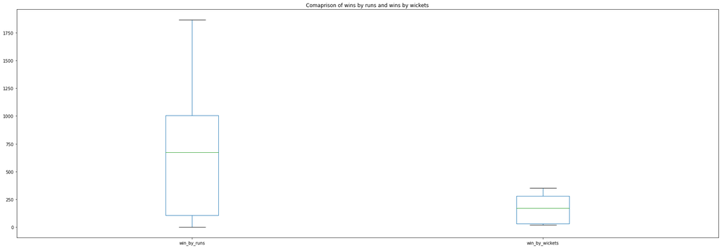

```python
d=d_matches.pivot_table(index=['winner'],values=['win_by_runs','win_by_wickets'],aggfunc=sum)
d.plot(kind='box',figsize=(30,10))
plt.title('Comaprison of wins by runs and wins by wickets')
plt.show()
```

### 7. Comaparing the number of matches held in home city and away

```python
df=pd.pivot_table(data=d_team_hna,values=['home_matches','away_matches'],index='team',aggfunc='sum').sort_values(by=['home_matches','away_matches'])
fig = make_subplots(rows=1, cols=2)

fig.add_trace(go.Scatter(x=df.index, y=df.home_matches.values,name='Home Matches'),
    row=1, col=1)

fig.add_trace(
    go.Scatter(x=df.index, y=df.away_matches.values,name='Away Matches'),
    row=1, col=2)

fig.update_layout(height=600, width=800, title_text="Comparison of matches played in home city and away")
fig.show()
```

[interactive chart not shown]

# Observations

1.The number of matches held in Mumbai city is the highest followed by Kolkata and Delhi.The number of matches held in each city between 2008 to 2019 can be observed.

2.The number of matches won by each team after winning the toss can be found.In the dataset Chennai Super Kings has won the highest number of matches after winning the toss.

3.Mumbai Indians has had the most number of wins in their home city.Similarly this information the number of matches won by each team in their home city can be observed.

4.Also it is possible to compare the number of wins at home city and away for each team.

5.In the Season IPL-2019 Mumbai Indians procured the most number of wins in matches held followed by Chennai Super Kings.

6.We can find the distribution of wins by runs and wins by wickets throughout the Seasons 2008 to 2019.

7.Comparing the number of matches played by each team in their home city and away using subplots.